# Video Games Market Investment

Huy Huynh

4/16/2020

## Introduction:

Over a few decades, gaming has been at the heart of the entertainment business across the globe. In fact, among gaming, video games are the most booming entertainment business that people of all ages enjoy them very much. Hence, they are reshaping how human beings interact with the world.

Importantly, they economically contribute enormous revenues to local as well as regional markets. The gaming industry has been driving companies like Google, Microsoft, or Sony to create new games with new ideas and innovation to satisfy the billions of gamers’ demand around the world. However, consumers’ demand engage with games is constantly changing. Therefore, the aim of this project is to observe consumption of video games around the world and analyze the trends in the popularity of genre.

By manipulating this data, developers and companies obviously obtain helpful information such as the most popular genres and regions with high levels of video game consumption, which give them a hint how to develope a successful video game launch along with popularity generes.

## Packages Required:

```r
#install.packages("kableExtra")
#install.packages('tinytex')
#install.packages("corrplot")
```

```r
library(dplyr) # Data Manipulation
library(plyr) # Set Combination
library(tidyverse) # Data Wraggling
```

```r
library(ggplot2) # Data Visualization
library(knitr) # Table Custom
library(kableExtra) # Table Custom
library(corrplot) # Correlogram
```

## Data Preparation

The dataset was compiled from a network known as vgchartz. The script to scrape the data is available at https://github.com/GregorUT/vgchartzScrape.

Vgchartz collects their data through calculated estimates, polls with video game retailers and video game communities, studying resale prices to determine popularity and consulting directly with developers and retail stores

The dataset was completed late October of 2016, the video game sales for November and December have not been input. Hence, this obvisouly presents a possible issue for 2016 trends since November and December often produce the highest sales during the year.

In addition, video games for former game platforms such as the PS3 have been discountinued which will inevitably reduce sales regardless of popularity.

```r
# Load data
vgsales = read.csv("vgsales.csv")
```

```r
# Quick Look at Variable Names in this data set
glimpse(vgsales)
```

```
## Observations: 16,598
## Variables: 11
## $ Rank         <int> 1, 2, 3, 4, 5, 6, 7, 8, 9, 10, 11, 12, 13, 14, 15, 16, 1…
## $ Name         <fct> Wii Sports, Super Mario Bros., Mario Kart Wii, Wii Sport…
## $ Platform     <fct> Wii, NES, Wii, Wii, GB, GB, DS, Wii, Wii, NES, DS, DS, G…
## $ Year         <fct> 2006, 1985, 2008, 2009, 1996, 1989, 2006, 2006, 2009, 19…
## $ Genre        <fct> Sports, Platform, Racing, Sports, Role-Playing, Puzzle, …
## $ Publisher    <fct> Nintendo, Nintendo, Nintendo, Nintendo, Nintendo, Ninten…
## $ NA_Sales     <dbl> 41.49, 29.08, 15.85, 15.75, 11.27, 23.20, 11.38, 14.03, …
## $ EU_Sales     <dbl> 29.02, 3.58, 12.88, 11.01, 8.89, 2.26, 9.23, 9.20, 7.06,…
## $ JP_Sales     <dbl> 3.77, 6.81, 3.79, 3.28, 10.22, 4.22, 6.50, 2.93, 4.70, 0…
## $ Other_Sales  <dbl> 8.46, 0.77, 3.31, 2.96, 1.00, 0.58, 2.90, 2.85, 2.26, 0.…
## $ Global_Sales <dbl> 82.74, 40.24, 35.82, 33.00, 31.37, 30.26, 30.01, 29.02, …
```

```r
# Quick look at top 5 rows of data
head(vgsales)
```

```
##   Rank                     Name Platform Year        Genre Publisher NA_Sales
## 1    1               Wii Sports      Wii 2006       Sports  Nintendo    41.49
## 2    2        Super Mario Bros.      NES 1985     Platform  Nintendo    29.08
## 3    3           Mario Kart Wii      Wii 2008       Racing  Nintendo    15.85
## 4    4        Wii Sports Resort      Wii 2009       Sports  Nintendo    15.75
## 5    5 Pokemon Red/Pokemon Blue       GB 1996 Role-Playing  Nintendo    11.27
## 6    6                   Tetris       GB 1989       Puzzle  Nintendo    23.20
##   EU_Sales JP_Sales Other_Sales Global_Sales
## 1    29.02     3.77        8.46        82.74
## 2     3.58     6.81        0.77        40.24
## 3    12.88     3.79        3.31        35.82
## 4    11.01     3.28        2.96        33.00
## 5     8.89    10.22        1.00        31.37
## 6     2.26     4.22        0.58        30.26
```

```r
# Quick look at bottom 5 rows of data
tail(vgsales)
```

```
##        Rank                                             Name Platform Year
## 16593 16595                                         Plushees       DS 2008
## 16594 16596               Woody Woodpecker in Crazy Castle 5      GBA 2002
## 16595 16597                    Men in Black II: Alien Escape       GC 2003
## 16596 16598 SCORE International Baja 1000: The Official Game      PS2 2008
## 16597 16599                                       Know How 2       DS 2010
## 16598 16600                                 Spirits & Spells      GBA 2003
##            Genre  Publisher NA_Sales EU_Sales JP_Sales Other_Sales Global_Sales
## 16593 Simulation  Destineer     0.01     0.00        0           0         0.01
## 16594   Platform      Kemco     0.01     0.00        0           0         0.01
## 16595    Shooter Infogrames     0.01     0.00        0           0         0.01
## 16596     Racing Activision     0.00     0.00        0           0         0.01
## 16597     Puzzle   7G//AMES     0.00     0.01        0           0         0.01
## 16598   Platform    Wanadoo     0.01     0.00        0           0         0.01
```

```r
summary(vgsales)
```

```
##       Rank                                Name          Platform
##  Min.   :    1   Need for Speed: Most Wanted:   12   DS     :2163
##  1st Qu.: 4151   FIFA 14                    :    9   PS2    :2161
##  Median : 8300   LEGO Marvel Super Heroes   :    9   PS3    :1329
##  Mean   : 8301   Madden NFL 07              :    9   Wii    :1325
##  3rd Qu.:12450   Ratatouille                :    9   X360   :1265
##  Max.   :16600   Angry Birds Star Wars      :    8   PSP    :1213
##                  (Other)                    :16542   (Other):7142
##       Year               Genre                             Publisher
##  2009   :1431   Action      :3316   Electronic Arts             : 1351
##  2008   :1428   Sports      :2346   Activision                  :  975
##  2010   :1259   Misc        :1739   Namco Bandai Games          :  932
##  2007   :1202   Role-Playing:1488   Ubisoft                     :  921
##  2011   :1139   Shooter     :1310   Konami Digital Entertainment:  832
##  2006   :1008   Adventure   :1286   THQ                         :  715
##  (Other):9131   (Other)     :5113   (Other)                     :10872
##     NA_Sales          EU_Sales          JP_Sales         Other_Sales
##  Min.   : 0.0000   Min.   : 0.0000   Min.   : 0.00000   Min.   : 0.00000
##  1st Qu.: 0.0000   1st Qu.: 0.0000   1st Qu.: 0.00000   1st Qu.: 0.00000
##  Median : 0.0800   Median : 0.0200   Median : 0.00000   Median : 0.01000
##  Mean   : 0.2647   Mean   : 0.1467   Mean   : 0.07778   Mean   : 0.04806
##  3rd Qu.: 0.2400   3rd Qu.: 0.1100   3rd Qu.: 0.04000   3rd Qu.: 0.04000
##  Max.   :41.4900   Max.   :29.0200   Max.   :10.22000   Max.   :10.57000
##
##   Global_Sales
##  Min.   : 0.0100
##  1st Qu.: 0.0600
##  Median : 0.1700
##  Mean   : 0.5374
##  3rd Qu.: 0.4700
##  Max.   :82.7400
##
```

Although video games are popular across the globe, understanding some largest markets and popular genre type is extremely important for developers in hit the point and increase their market. According to the above general summary, Action is the most popular genre among video games and North America, Europe, and Japan are the biggest markets contributing to gobal sale. With a quick glimpse, North America almost takes over portion in whole wolrd sale, which indicates this is the most potential market.

```r
vgsales$Year <- as.numeric(as.character(vgsales$Year))
vgsales<- na.omit(vgsales)
# In order to get better data visualization, this function is good to return the data with listwise deletion of missing values.
```

## Exploratory Data Analysis

Let’s take a look at Sales Trend across the market

```r
# Using aggregate() function in R to create the sum of all sales across regions and group by Year
Global.trend<-aggregate(vgsales$Global_Sales, by=list(Year=vgsales$Year), FUN=sum)
NA.trend<-aggregate(vgsales$NA_Sales, by=list(Year=vgsales$Year), FUN=sum)
EU.trend<-aggregate(vgsales$EU_Sales, by=list(Year=vgsales$Year), FUN=sum)
JP.trend<-aggregate(vgsales$JP_Sales, by=list(Year=vgsales$Year), FUN=sum)
Other.trend<-aggregate(vgsales$Other_Sales, by=list(Year=vgsales$Year), FUN=sum)
```

```r
#Creating a join subset to demonstrate Sale Trend
EU.sales<-EU.trend$x
NA.sales<-NA.trend$x
JP.sales<-JP.trend$x
Other.sales<-Other.trend$x
Global.sales<- Global.trend$x
year<-NA.trend$Year
Sale_trend.df<-data.frame(year, NA.sales, EU.sales, JP.sales, Other.sales,Global.sales)
```

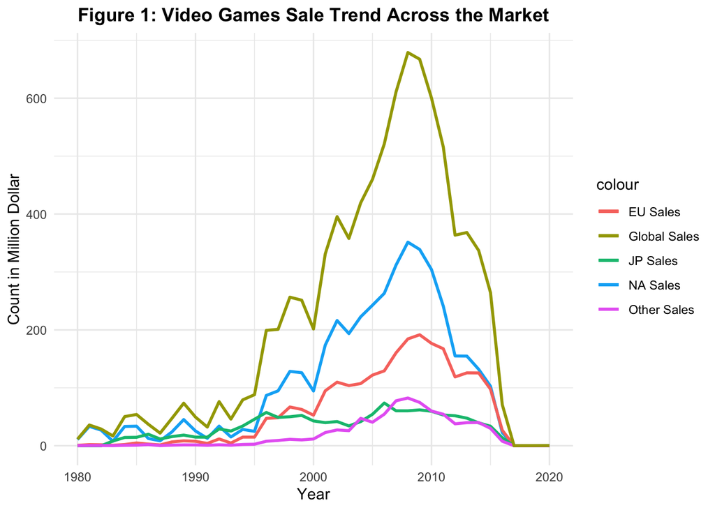

```r
ggplot(Sale_trend.df, aes(x= year,group = 1)) +
  geom_line(aes(y = NA.sales , colour = "NA Sales"),size=1) +
  geom_line(aes( y = EU.sales, colour = "EU Sales"),size=1)+
  geom_line(aes( y= JP.sales, colour='JP Sales'),size=1)+
  geom_line(aes( y= Other.sales,colour='Other Sales'),size=1) +
  geom_line(aes( y= Global.sales, colour = "Global Sales"), size = 1 ) +
  ylab('Count in Million Dollar') +
  xlab('Year') +
  ggtitle(label = "Figure 1: Video Games Sale Trend Across the Market") +
  theme_minimal() +
  theme(plot.title = element_text(hjust=0.5,face='bold'))
```

The sales trend depicts that the sales at all regions across the globe has rapidly increased over the time and its peaks is in 2008. However, since that year, the market sales started to be falling downfowrad. Whatever the sale trend is, North America (NA), Europe (EU), and Japan(JP) are the most heavily consumed video games market.

Is there any evidence of differences between sales in different regions of the world?

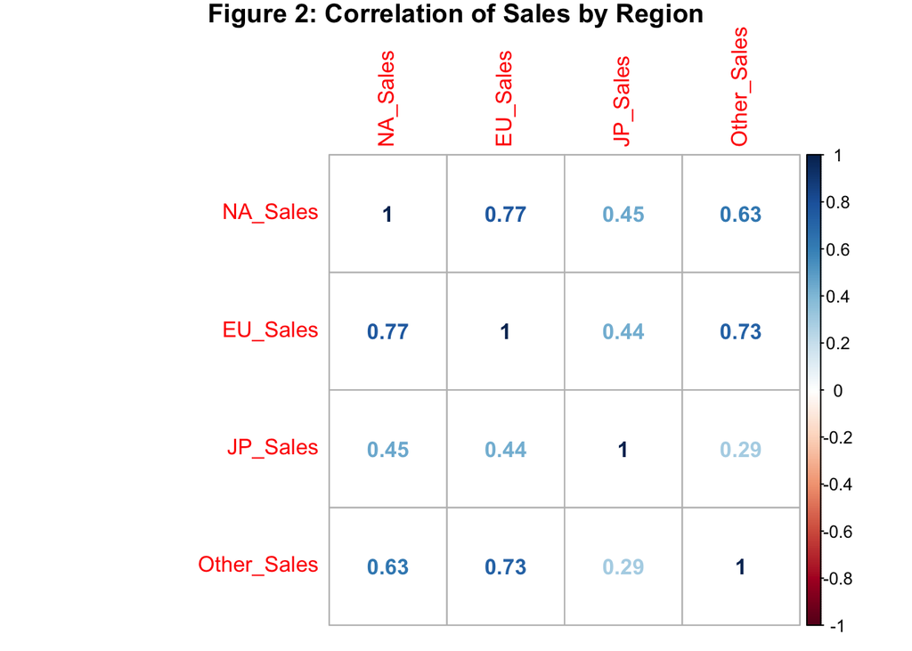

```r
sales <- vgsales[,c("NA_Sales","EU_Sales","JP_Sales","Other_Sales")]
S <- cor(sales)
corrplot(S, method = "number", title = "Figure 2: Correlation of Sales by Region", mar=c(0,0,1,0))
```

But what is the exact percenatge of North America sale contributing to Global sales?

```r
NA_vs_Global <- NA.trend$x/Global.trend$x * 100
summary(NA_vs_Global)
```

```
##    Min. 1st Qu.  Median    Mean 3rd Qu.    Max.
##    0.00   40.82   50.17   50.40   52.92   93.37
```

Now, we take a look at the top 10 Publisher regarding to regarding to Global Revenue

```r
#Using aggregate() function in R to create the sum of global sales across rand group by Publisher
TopPublishers <- aggregate(vgsales$Global_Sales,list(vgsales$Publisher),sum)
TopPublishers <- TopPublishers[with(TopPublishers, order(-x)), ]
rownames(TopPublishers) <- NULL
```

```r
#Selecting only Top 10 of the list
Top10Publishers <- head(TopPublishers, 10) %>%
  rename(c("Group.1" = "Publishers", "x" = "Total Sale"))
```

```r
# This package allows me to modify a table with desirable variables
kable(Top10Publishers, caption = "Figure 3: A Table of Top 10 Publishers", booktabs = T) %>%
  kable_styling(full_width = T) %>%
  column_spec(1, bold = T,border_right = T, width = 40 ,color = "red")
```

Figure 3: A Table of Top 10 Publishers

| Publishers | Total Sale |
| --- | --- |
| Nintendo | 1784.43 |
| Electronic Arts | 1093.39 |
| Activision | 721.41 |
| Sony Computer Entertainment | 607.28 |
| Ubisoft | 473.54 |
| Take-Two Interactive | 399.30 |
| THQ | 340.44 |
| Konami Digital Entertainment | 278.56 |
| Sega | 270.70 |
| Namco Bandai Games | 253.65 |

Nintendo is the publisher having the top sale and outstanding from the others.

In which genre has most of the games released?

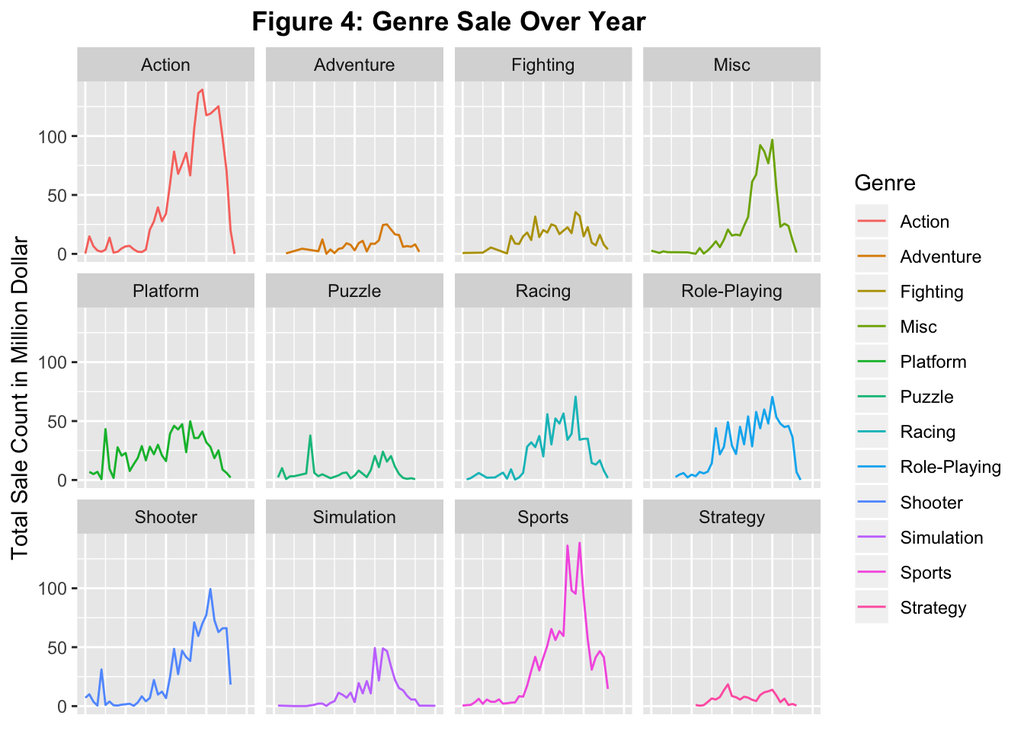

```r
GenreByYear <- aggregate(vgsales$Global_Sales,list(vgsales$Genre, vgsales$Year),sum)
colnames(GenreByYear) <- c("Genre", "Year", "TotalSales")

ggplot(GenreByYear) +
  geom_line(aes(x=Year, y=TotalSales, colour=Genre)) +
  facet_wrap(~Genre) +
  theme(axis.title.x=element_blank(),
        axis.text.x=element_blank(),
        axis.ticks.x=element_blank(),
        plot.title = element_text(hjust=0.5,face='bold')) +
  ylab("Total Sale Count in Million Dollar") +
  ggtitle(label = "Figure 4: Genre Sale Over Year")
```

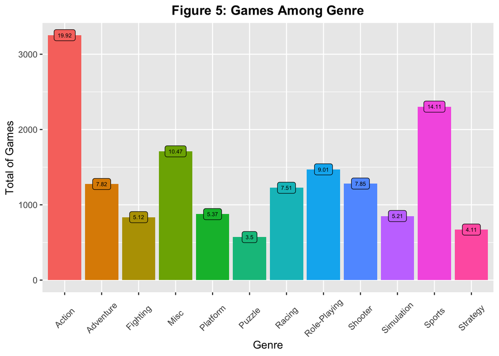

```r
vgsales %>%
  select(Genre) %>%
  group_by(Genre) %>%
  dplyr::summarise(count = n()) %>%
  arrange(desc(count)) %>%
  mutate(Percentage = round(count/sum(count) *100, digits = 2)) %>%
  ggplot(aes(Genre,count,fill=Genre))+
  geom_bar(stat="identity")+
  geom_label(aes(label= Percentage),size=2)+
  theme(axis.text.x = element_text(angle=45,vjust =0.5, hjust = 0.5),
        plot.title = element_text(hjust=0.5,face='bold'),
        legend.position="none") +
  ggtitle("Figure 5: Games Among Genre")+
  labs(x="Genre",y="Total of Games")
```

How about taking a look of top 10 games that are dominant in North America.

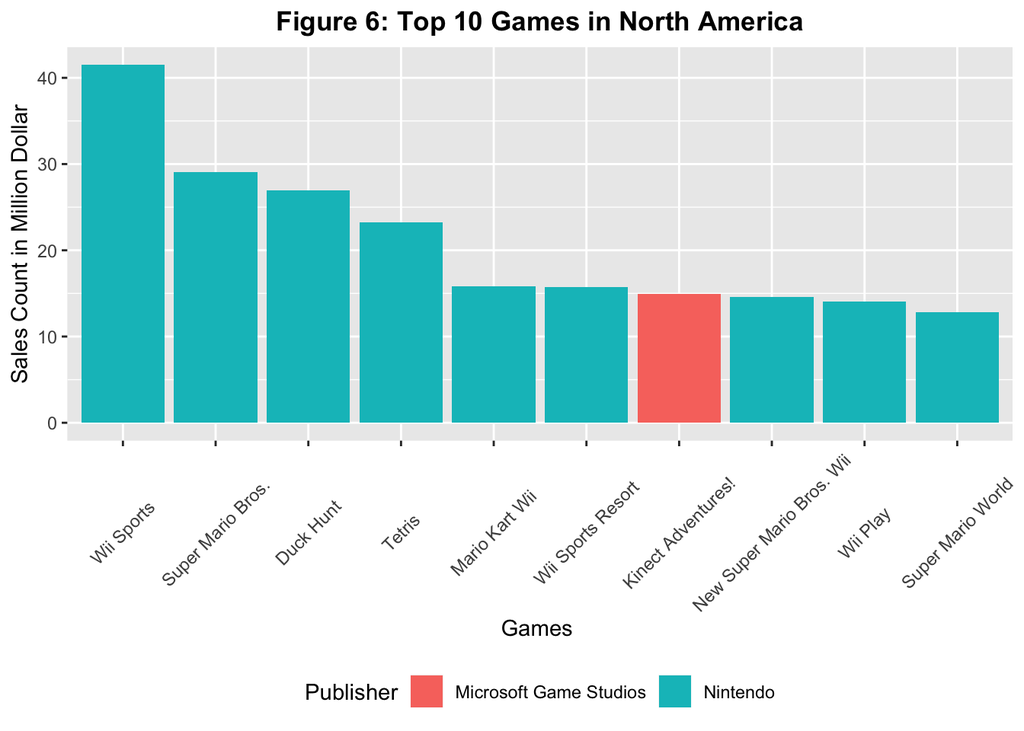

```r
NA_top10 <- vgsales %>%
  select(Name,NA_Sales,Publisher) %>%
  arrange(desc(NA_Sales))
ggplot(head(NA_top10,10),aes(factor(Name,levels=Name),NA_Sales,fill=Publisher))+
  geom_bar(stat="identity")+
  theme(axis.text.x = element_text(angle=45,vjust=0.5, hjust = 0.5),plot.title = element_text(hjust=0.5,face='bold'),legend.position="bottom") +
  ggtitle("Figure 6: Top 10 Games in North America") +
  labs(x="Games ",y="Sales Count in Million Dollar")
```

Wii Sports from Nintendo is the best selling game in North America. Since this game contains multiple games inside, consumers tend to purchase this type which is easily accessible for both adults and children.

Following previous Genre Analysis, I wonder if Action is still the most popular Genre in North America - the targeted market?

Now, we could take a look of game genre among different regions as well as in the term of global aspect.

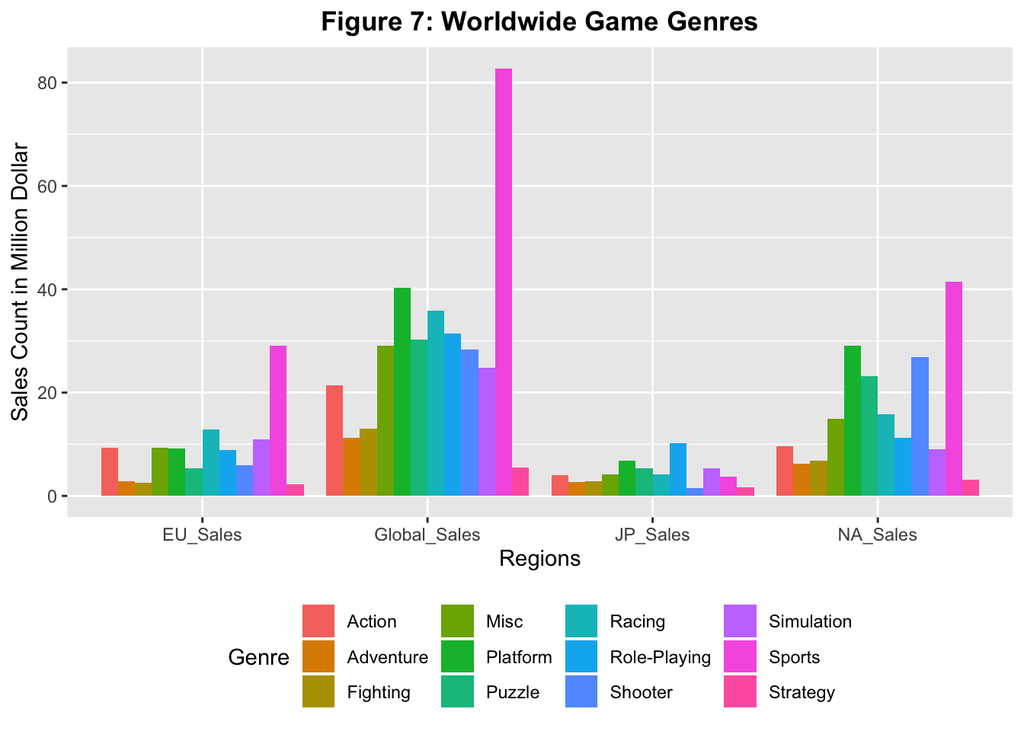

```r
temp<- vgsales %>% select(Genre,EU_Sales,JP_Sales,NA_Sales,Global_Sales)
temp<- gather(temp,region,sales,2:5)
  ggplot(temp,aes(region,sales,fill=Genre))+
  geom_bar(stat="identity",position=position_dodge())+
  theme(plot.title = element_text(hjust=0.5,face='bold'), legend.position="bottom") +
  ggtitle("Figure 7: Worldwide Game Genres")+
  labs(x="Regions",y="Sales Count in Million Dollar")
```

Supringsingly, Sports is the greatest genre in the Global Sales. In level of region, it was consumed favoritely higher in Europe,and North America. That explains why Wii Sports has become dominent in North America market as it follows the global trend.

## Summary:

North America is the most heavily consumer for video game market followed by Europe and Japan. Across the globe, the sale market was increasing rapidly until 2008 for all of regions.In spite of growth in video game over the past few decades, sales of recent releases appear to be lower than that of older games. In fact, sales had tendency to going downforward since 2008 and continued to the end of 2016. This trend was somehome related to the Global Economic Crisis that peopel lost jobs, had to stay at home and enjoyed video games. And after 2008, although so many video games were released but the sale was going down because of economy recovery and growth. As a result, the same trend is about to happen again with Covid 19, which indicates this could be a good time for game developers to spedd up and release new products to the market in order to satisfy customers demand and make profit. In addition, ultilizing above analysis, in the future, they should at times release new videos in order to avoid overwhelming damage cost to the companies as well as ineffective sales in the market.

Further analysis might help to identify when a customer is looking to purchase a new system for video games, the types of games that they want to play will likely influence the decision. According to my own video game experiences, the Nintendo may be the best option for those who are looking for platform games and the ability to play sports and action games. But more stastical analysis is more higly recommended to provide further information.